# Bai4_Baitap1

Pham Ngoc Anh

2025-02-05

```r
getwd()
```

```
## [1] "/Users/pna"
```

## Bài tập 4

### a. Xây dựng hàm mục tiêu để ước lượng cho các tham số r và K của mô hình, sao cho sai số của mô hình là nhỏ nhất

Ta có:

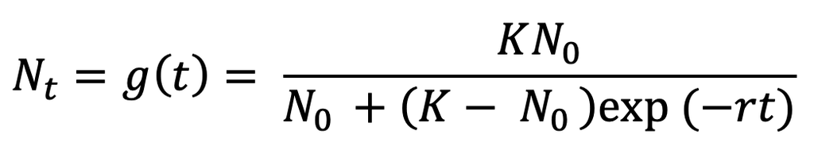

với $N_t$ là kích thước quần thể tại thời điểm t. Ta xây dựng hàm mục tiêu để cho Tổng bình phương sai số (SSE) là nhỏ nhất:

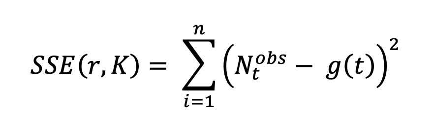

với $N_t^{obs}$ là kích thước quần thể quan sát được (lấy từ tệp dữ liệu) và $g(t)$ là kích thước quần thể tính được theo phương trình đã cho.

### b. Viết các bước giải thuật để xác định ước lượng của r và K bằng phương pháp Newton

Phương pháp Newton có phương trình nghiệm lặp như sau:

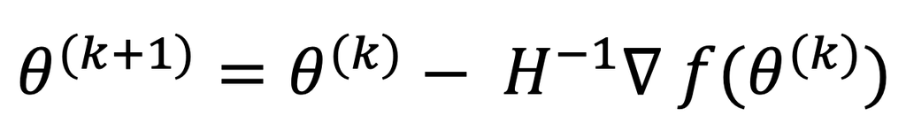

Các bước giải thuật:  
1. Giả định giá trị ban đầu của các tham số $r$ và $K$  
2. Tính gradient $∇f$ bằng đạo hàm riêng của SSE theo $r$ và $K$  
3. Tính ma trận Hessian bằng đạo hàm bậc 2 của SSE  
4. Cập nhật các tham số $r$ và $K$ sử dụng phương trình nghiệm lặp  
$θ^{(k+1)}=θ^{(k)}- H^{(-1)} ∇ f(θ^{(k)})$ 5. Tiếp tục cho đến khi hết vòng lặp (40 vòng lặp)

```r
library(readr)
library(MASS)
```

Note: Việc 2 cột trong tập dữ liệu nằm trong các khoảng giá trị khác nhau sẽ gây ra lỗi trong tính toán, do đó cần áp dụng các phương pháp chuẩn hoá dữ liệu để đưa các biến về cùng khoảng giá trị. Trong bài này, phương pháp Standardization.

```r
data_b <- read_delim(file = "~/Documents/Kao học/TKTT/bai tap 1_thong ke tinh toan/beetles.csv")
head(data_b)
```

```
## # A tibble: 6 × 2
##    days beetles
##   <dbl>   <dbl>
## 1     0       2
## 2     8      47
## 3    28     192
## 4    41     256
## 5    63     768
## 6    79     896
```

```r
N_t <- data_b$beetles
t <- data_b$days
C_N_t <- abs(min(N_t - mean(N_t))) + 1e-5
C_t <- abs(min(t - mean(t))) + 1e-5


t <- t_scaled <- (t - mean(t)+C_t) / sd(t)
N_t <- N_t_scaled <- (N_t - mean(N_t)+C_N_t) / sd(N_t)


N0 <- N_t[1]
```

```r
compute_SSE <- function(para, t, N0) {

    K <- para[2]
    r <- para[1]

    g_t <- (K * N0)/ (N0 + (K - N0) * exp(-r * t))
    SSE <- sum((N_t - g_t)^2)  # Compute SSE
    return(SSE)
}
```

```r
first_prime <- function(para, t, N0) {
    #para = (r, K)

    K <- para[2]
    r <- para[1]

    g_t <- (K*N0) / (N0 + (K - N0) * exp(-r*t))
    g_prime_r <- g_t * exp(-r*t) * t * (K-N0) / (N0 + (K-N0) * exp(-r*t))
    g_prime_k <- (N0 - g_t * exp(-r*t)) / (N0 + (K-N0) * exp(-r*t))

    res <- numeric(2)
    res[1] <- -2 * sum((N_t - g_t) * (g_t * exp(-r*t) * t * (K-N0)) / (N0 + (K-N0) * exp(-r*t)))
    res[2] <- -2 * sum((N_t - g_t) * (N0 - g_t * exp(-r*t)) / (N0 + (K-N0) * exp(-r*t)))
    return(res)
}
```

```r
second_prime <- function(para, t, N0) {

    K <- para[2]
    r <- para[1]

    g_t <- K * N0 / (N0 + (K - N0) * exp(-r*t))
    g_prime_r <- g_t * exp(-r*t) * t * (K-N0) / (N0 + (K-N0) * exp(-r*t))
    g_prime_k <- (N0 - g_t * exp(-r*t)) / (N0 + (K-N0) * exp(-r*t))

    A <- exp(-r*t) * (K - N0) + t
    B <- g_t * exp(-r*t) * t * (K-N0)
    C <- 2 * g_prime_k * exp(-r*t) / (N0 + (K-N0) * exp(-r*t))
    D <- exp(-r*t) / (N0 + (K-N0) * exp(-r*t))
    E <- g_t*t - g_prime_r + g_prime_k*(K-N0)

    res <- matrix(0, nrow = 2, ncol = 2)
    res[1,1] <- -2 * sum(g_prime_r  * (A - B) / (N0 + (K - N0) * exp(-r*t)))
    res[2,2] <- -2 * sum(g_prime_k^2 + (N_t - g_t) * C)
    res[1,2] <- res[2,1] <- 2 * sum(g_prime_k * g_prime_r - (N_t - g_t) * D * E)

    res <- res +  diag(1e-5, 2)

    return(res)
}
```

```r
par_0 <- c(100,200)
iter <- 40
par_est <- matrix(0, nrow = iter + 1, ncol = 2)
par_est[1, ] <- par_0
```

```r
SSE_values <- numeric(iter + 1)
SSE_values[1] <- compute_SSE(para = par_0, t=t, N0=N0)

for (i in 1:iter) {
    score <- first_prime(para = par_0, t = t, N0 = N0)
    hess <- second_prime(para = par_0, t = t, N0 = N0)

    par_0 <- par_0 - solve(hess) %*% score
    par_est[i+1, ] <- par_0
    SSE_values[i+1] <- compute_SSE(para = par_0, t=t, N0=N0)  # Compute SSE for each iteration

    return(par_est)
    return(SSE_values)
}

## Print final SSE values
par_est
```

```
##            [,1]     [,2]
##  [1,] 100.00000 200.0000
##  [2,]  99.99999 398.2933
##  [3,]   0.00000   0.0000
##  [4,]   0.00000   0.0000
##  [5,]   0.00000   0.0000
##  [6,]   0.00000   0.0000
##  [7,]   0.00000   0.0000
##  [8,]   0.00000   0.0000
##  [9,]   0.00000   0.0000
## [10,]   0.00000   0.0000
## [11,]   0.00000   0.0000
## [12,]   0.00000   0.0000
## [13,]   0.00000   0.0000
## [14,]   0.00000   0.0000
```

[output cut: 27 more lines]

```r
SSE_values
```

```
##  [1]  314566.1 1258251.4       0.0       0.0       0.0       0.0       0.0
##  [8]       0.0       0.0       0.0       0.0       0.0       0.0       0.0
## [15]       0.0       0.0       0.0       0.0       0.0       0.0       0.0
## [22]       0.0       0.0       0.0       0.0       0.0       0.0       0.0
## [29]       0.0       0.0       0.0       0.0       0.0       0.0       0.0
## [36]       0.0       0.0       0.0       0.0       0.0       0.0
```

=> Mô hình cho thấy không có nghiệm lặp khi sử dụng phương pháp Newton. Ngoài ra, SSE của model tăng chứ không được tối thiểu hoá.

### c. Viết các bước giải thuật để xác định ước lượng của r và K bằng phương pháp quasi- Newton. Viết một chương trình thi hành giải thuật này. So sánh với kết quả câu (b).

Các bước giải thuật:  
1. Khởi tạo $α^{(t)}$ = 1 và chọn $M^{(t)}$  
2. Xác định $x^{(t+1)}$

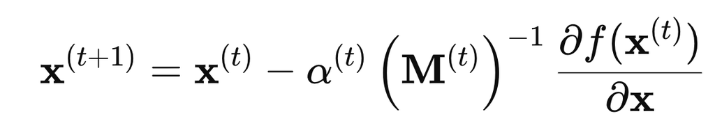

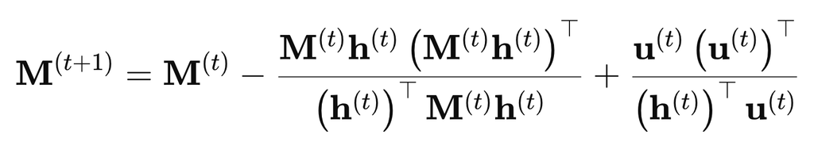

trong đó,

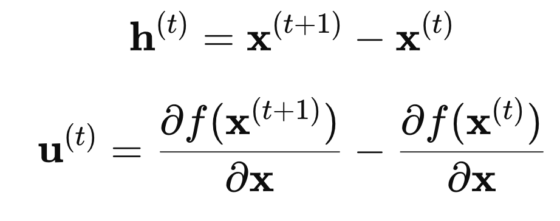

Nếu $|(v^{(t)})⊤*v^{(t)}|<ϵ$ thì $M^{(t+1)}$ = $M^{(t)}$.Nếu không thì đi tiếp với $M^{(t+1)}$ đã tính.

```r
alpha_default <- 1
alpha <- alpha_default
M <- diag(c(-1, -1), 2, 2)
iter <- 20
par_bfgs_0 <- c(100, 200)
par_bfgs <- matrix(0, nrow = iter + 1, ncol = 2)
par_bfgs[1, ] <- par_bfgs_0
epsilon <- 1e-10
```

```r
SSE_values <- numeric(iter + 1)
SSE_values[1] <- compute_SSE(para = par_bfgs_0, t=t, N0=N0)


for (i in 1:iter) {

    hessian_inv <- solve(M)
    score <- first_prime(para = par_bfgs_0, t = t, N0 = N0)
    alpha*hessian_inv %*% score

    par_t <- par_bfgs_0 - alpha * hessian_inv %*% score

    #REDUCE ALPHA UNTIL A CORRECT STEP IS REACHED
    f_t <- compute_SSE(para = par_t, t = t, N0 = N0)
    f_t0 <- compute_SSE(para = par_bfgs_0, t = t, N0 = N0)

    while (f_t > f_t0) {
        # chừng nào f_t < f_t0 thì cập nhật lại alpha và tính lại par_t
        alpha <- alpha*2
        par_t <- par_bfgs_0 - alpha * hessian_inv %*% score
        f_t <- compute_SSE(para = par_t, t = t, N0 = N0)
    }

    par_bfgs[i+1, ] <- par_t
    SSE_values[i+1] <- compute_SSE(para = par_0, t=t, N0=N0)  # Compute SSE for each iteration

    ## UPDATE M(t)
    ht = par_t - par_bfgs_0
    score_t <- first_prime(para = par_t, t = t, N0 = N0)
    ut <- score_t - score
    v <- ut - M %*% ht
    M_old <- M
    M <- M - ((M %*% ht %*% t(M %*% ht))/(as.numeric(t(ht) %*% M %*% ht))) +
                ((ut %*% t(ut))/(as.numeric(t(ht) %*% ut)))
    # CHECK CONDITION TO UPDATE M
    if (abs((t(v) %*% ht)[1]) < epsilon) {
                M <- M_old
            }
    # RESET alpha and x0
    alpha <- alpha_default
    par_bfgs_0 <- par_t
}
```

```r
print(par_bfgs)
```

```
##            [,1]      [,2]
##  [1,] 100.00000       200
##  [2,] -51.04015 831702107
##  [3,] -51.04015 831702107
##  [4,] -51.04015 831702107
##  [5,] -51.04015 831702107
##  [6,] -51.04015 831702107
##  [7,] -51.04015 831702107
##  [8,] -51.04015 831702107
##  [9,] -51.04015 831702107
## [10,] -51.04015 831702107
## [11,] -51.04015 831702107
## [12,] -51.04015 831702107
## [13,] -51.04015 831702107
## [14,] -51.04015 831702107
## [15,] -51.04015 831702107
## [16,] -51.04015 831702107
## [17,] -51.04015 831702107
## [18,] -51.04015 831702107
## [19,] -51.04015 831702107
## [20,] -51.04015 831702107
## [21,] -51.04015 831702107
```

```r
print(SSE_values)
```

```
##  [1]  314566.1 1258251.4 1258251.4 1258251.4 1258251.4 1258251.4 1258251.4
##  [8] 1258251.4 1258251.4 1258251.4 1258251.4 1258251.4 1258251.4 1258251.4
## [15] 1258251.4 1258251.4 1258251.4 1258251.4 1258251.4 1258251.4 1258251.4
```

=> Nghiệm cũng không lặp ở phương pháp này. Tương tự với phương pháp Newton, SSE không được tối thiểu hoá.

#### Phương pháp Newton:

```r
epsilon <- 1e-8  # Small positive value to avoid log(0)
lambda <- max(1e-3, 1e-1 * max(abs(hess)))
```

```r
logL_prime <- function(para, t, N0) {
    # para = (r, K, var2)
    K <- para[2]
    r <- para[1]
    var2 <- para[3]
    n <- length(N_t)

    g_t <- K * N0 / (N0 + (K - N0) * exp(-r*t))
    g_t[g_t < epsilon] <- epsilon  # Ensure g_t is never zero or negative
    g_prime_r <- g_t * exp(-r*t) * t * (K-N0) / (N0 + (K-N0) * exp(-r*t))
    g_prime_k <- (N0 - g_t * exp(-r*t)) / (N0 + (K-N0) * exp(-r*t))

    res <- numeric(3)
    dl_dr <- res[1] <- -1/var2 * sum((log(N_t) - log(g_t)) * g_prime_r/g_t)
    dl_dk <- res[2] <- -1/var2 * sum((log(N_t) - log(g_t)) * g_prime_k/g_t)
    dl_dvar2 <- res[3] <- -n/(2*var2) + 1/(2*var2^2) * sum((log(N_t) - log(g_t))^2)

    return(res)
}
```

```r
logL_2prime <- function(para, t, N0) {
        # para = (r, K, var2)
    K <- para[2]
    r <- para[1]
    var2 <- para[3]
    n <- length(N_t)

    g_t <- K * N0 / (N0 + (K - N0) * exp(-r*t))
    g_t[g_t < epsilon] <- epsilon  # Ensure g_t is never zero or negative
    g_prime_r <- g_t * exp(-r*t) * t * (K-N0) / (N0 + (K-N0) * exp(-r*t))
    g_prime_k <- (N0 - g_t * exp(-r*t)) / (N0 + (K-N0) * exp(-r*t))

    res <- matrix(0, nrow = 3, ncol = 3)
    d2l_dr2 <- res[1,1] <- -sum((g_prime_r/g_t)^2)/var2
    d2l_drdk <- res[1,2] <- res[2,1] <- -sum(g_prime_r * g_prime_k / g_t)/var2
    d2l_drdvar2 <- res[1,3] <- res[3,1] <- sum((log(N_t) - log(g_t))* g_prime_r/g_t)/(var2^2)
    d2l_dkdvar2 <- res[2,3] <- res[3,2] <- sum((log(N_t) - log(g_t))* g_prime_k/g_t)/(var2^2)
    d2l_dk2  <- res[2,2] <- -sum((g_prime_k/g_t)^2)/var2
    d2l_dvar2_2 <- res[3,3] <- n/(2*(var2)^2) - sum((log(N_t) - log(g_t))^2)/((var2)^4)

    return(res)
}
```

```r
par_0 <- c(200,300,400)
iter <- 100
par_est <- matrix(0, nrow = iter + 1, ncol = 3)
relative_err_est <- matrix(0, nrow = iter + 1, ncol = 3)
abs_err_est <- matrix(0, nrow = iter + 1, ncol = 3)

par_est[1, ] <- par_0
relative_err_est[1, ] <- c(0,0,0)
abs_err_est[1, ] <- c(0,0,0)

for (i in 1:iter) {
    score <- logL_prime(para = par_0, t= t, N0 = N0)
    hess <- logL_2prime(para = par_0, t= t, N0 = N0)
    hess_reg <- hess + lambda * diag(nrow(hess))

    par_new <- par_0 - solve(hess_reg) %*% score

    abs_err <- abs(par_new - par_0)
    relative_err <- (abs(par_new - par_0)/abs(par_0))
    relative_err_est[i+1, ] <- relative_err
    abs_err_est[i+1, ] <- abs_err

    par_0 <- par_new

    par_est[i+1, ] <- par_0

}
```

```r
par_est
```

```
##            [,1]     [,2]     [,3]
##   [1,] 200.0000 300.0000 400.0000
##   [2,] 200.0000 299.9999 400.0023
##   [3,] 200.0000 299.9998 400.0046
##   [4,] 200.0000 299.9997 400.0069
##   [5,] 200.0000 299.9997 400.0092
##   [6,] 200.0000 299.9996 400.0115
##   [7,] 200.0000 299.9995 400.0138
##   [8,] 200.0000 299.9994 400.0161
##   [9,] 200.0000 299.9993 400.0184
##  [10,] 200.0000 299.9992 400.0207
##  [11,] 200.0000 299.9992 400.0230
##  [12,] 200.0000 299.9991 400.0253
##  [13,] 200.0000 299.9990 400.0276
##  [14,] 200.0000 299.9989 400.0299
```

[output cut: 87 more lines]

```r
relative_err_est
```

```
##                [,1]         [,2]         [,3]
##   [1,] 0.000000e+00 0.000000e+00 0.000000e+00
##   [2,] 3.993240e-09 2.798457e-07 5.749119e-06
##   [3,] 3.993217e-09 2.798442e-07 5.749056e-06
##   [4,] 3.993193e-09 2.798428e-07 5.748992e-06
##   [5,] 3.993169e-09 2.798413e-07 5.748929e-06
##   [6,] 3.993146e-09 2.798398e-07 5.748866e-06
##   [7,] 3.993122e-09 2.798384e-07 5.748802e-06
##   [8,] 3.993098e-09 2.798369e-07 5.748739e-06
##   [9,] 3.993074e-09 2.798354e-07 5.748675e-06
##  [10,] 3.993051e-09 2.798340e-07 5.748612e-06
##  [11,] 3.993027e-09 2.798325e-07 5.748549e-06
##  [12,] 3.993003e-09 2.798311e-07 5.748485e-06
##  [13,] 3.992979e-09 2.798296e-07 5.748422e-06
##  [14,] 3.992956e-09 2.798281e-07 5.748358e-06
```

[output cut: 87 more lines]

```r
abs_err_est
```

```
##                [,1]         [,2]        [,3]
##   [1,] 0.000000e+00 0.000000e+00 0.000000000
##   [2,] 7.986481e-07 8.395371e-05 0.002299648
##   [3,] 7.986433e-07 8.395325e-05 0.002299636
##   [4,] 7.986386e-07 8.395279e-05 0.002299623
##   [5,] 7.986338e-07 8.395232e-05 0.002299611
##   [6,] 7.986291e-07 8.395186e-05 0.002299599
##   [7,] 7.986243e-07 8.395140e-05 0.002299587
##   [8,] 7.986196e-07 8.395093e-05 0.002299575
##   [9,] 7.986148e-07 8.395047e-05 0.002299563
##  [10,] 7.986101e-07 8.395001e-05 0.002299551
##  [11,] 7.986054e-07 8.394954e-05 0.002299538
##  [12,] 7.986006e-07 8.394908e-05 0.002299526
##  [13,] 7.985959e-07 8.394862e-05 0.002299514
##  [14,] 7.985911e-07 8.394815e-05 0.002299502
```

[output cut: 87 more lines]

=> Không hội tụ

#### Phương pháp Fisher scoring

```r
par_0 <- c(200,300,400)
iter <- 40
par_est <- matrix(0, nrow = iter + 1, ncol = 3)
par_est[1, ] <- par_0

relative_err_est <- matrix(0, nrow = iter + 1, ncol = 3)
abs_err_est <- matrix(0, nrow = iter + 1, ncol = 3)
relative_err_est[1, ] <- c(0,0,0)
abs_err_est[1, ] <- c(0,0,0)
```

```r
n <- length(N_t)

for (i in 1:iter) {
    score <- logL_prime(para = par_0, t= t, N0 = N0)
    hess <- logL_2prime(para = par_0, t= t, N0 = N0)
    fisher <- -hess/n
    par_new <- par_0 - solve(hess) %*% score

    abs_err <- abs(par_new - par_0)
    relative_err <- (abs(par_new - par_0)/abs(par_0))
    relative_err_est[i+1, ] <- relative_err
    abs_err_est[i+1, ] <- abs_err

    par_0 <- par_new

    par_est[i+1, ] <- par_0
}
```

```r
par_est
```

```
##              [,1]     [,2]         [,3]
##  [1,]    200.0000 300.0000 4.000000e+02
##  [2,]    261.9506 300.5797 7.705966e+02
##  [3,] 348741.6507 300.2260 1.511664e+03
##  [4,] 355310.7285 332.1026 2.994853e+03
##  [5,] 358871.0277 351.1958 5.959698e+03
##  [6,] 360730.4977 361.7382 1.188852e+04
##  [7,] 361681.6316 367.2922 2.374568e+04
##  [8,] 362162.7637 370.1448 4.745978e+04
##  [9,] 362404.7514 371.5906 9.488785e+04
## [10,] 362526.1075 372.3185 1.897439e+05
## [11,] 362586.8708 372.6837 3.794560e+05
## [12,] 362617.2766 372.8666 7.588803e+05
## [13,] 362632.4852 372.9582 1.517729e+06
## [14,] 362640.0909 373.0040 3.035426e+06
```

[output cut: 27 more lines]

```r
relative_err_est
```

```
##               [,1]         [,2]      [,3]
##  [1,] 0.000000e+00 0.000000e+00 0.0000000
##  [2,] 3.097529e-01 1.932181e-03 0.9264915
##  [3,] 1.330326e+03 1.176627e-03 0.9616800
##  [4,] 1.883652e-02 1.061753e-01 0.9811635
##  [5,] 1.002024e-02 5.749197e-02 0.9899798
##  [6,] 5.181444e-03 3.001861e-02 0.9948186
##  [7,] 2.636688e-03 1.535360e-02 0.9973633
##  [8,] 1.330264e-03 7.766509e-03 0.9986697
##  [9,] 6.681741e-04 3.906164e-03 0.9993318
## [10,] 3.348633e-04 1.958871e-03 0.9996651
## [11,] 1.676108e-04 9.808908e-04 0.9998324
## [12,] 8.385805e-05 4.908102e-04 0.9999161
## [13,] 4.194111e-05 2.454964e-04 0.9999581
## [14,] 2.097358e-05 1.227711e-04 0.9999790
```

[output cut: 27 more lines]

```r
abs_err_est
```

```
##               [,1]         [,2]         [,3]
##  [1,] 0.000000e+00 0.000000e+00 0.000000e+00
##  [2,] 6.195059e+01 5.796544e-01 3.705966e+02
##  [3,] 3.484797e+05 3.536700e-01 7.410673e+02
##  [4,] 6.569078e+03 3.187659e+01 1.483189e+03
##  [5,] 3.560299e+03 1.909323e+01 2.964844e+03
##  [6,] 1.859470e+03 1.054241e+01 5.928818e+03
##  [7,] 9.511339e+02 5.553982e+00 1.185717e+04
##  [8,] 4.811321e+02 2.852578e+00 2.371410e+04
##  [9,] 2.419878e+02 1.445846e+00 4.742807e+04
## [10,] 1.213560e+02 7.278982e-01 9.485607e+04
## [11,] 6.076331e+01 3.652038e-01 1.897121e+05
## [12,] 3.040583e+01 1.829170e-01 3.794242e+05
## [13,] 1.520857e+01 9.153742e-02 7.588484e+05
## [14,] 7.605701e+00 4.578847e-02 1.517697e+06
```

[output cut: 27 more lines]

#### Phương pháp quasi Newton

```r
alpha_default <- 1
alpha <- alpha_default
M <- diag(c(-1, -1, -1), 3, 3)
iter <- 20
par_bfgs_0 <- c(200, 300, 400)
par_bfgs <- matrix(0, nrow = iter + 1, ncol = 3)
par_bfgs[1, ] <- par_bfgs_0
epsilon <- 1e-10
```

```r
relative_err_est <- matrix(0, nrow = iter + 1, ncol = 3)
abs_err_est <- matrix(0, nrow = iter + 1, ncol = 3)
relative_err_est[1, ] <- c(0,0,0)
abs_err_est[1, ] <- c(0,0,0)
```

```r
likelihood_function <- function(para, t, N0) {
    K <- para[2]
    r <- para[1]
    var2 <- para[3]
    n <- length(N_t)

    g_t <- K * N0 / (N0 + (K - N0) * exp(-r*t))
    g_t[g_t < epsilon] <- epsilon  # Ensure g_t is never zero or negative

    return(-n*log(2*pi*var2)/2 - sum((log(N_t) - log(g_t))^2)/(2*var2))

}
```

```r
for (i in 1:iter) {
    hessian_inv <- solve(M)
    score <- logL_prime(para = par_bfgs_0, t= t, N0 = N0)
    par_t <- par_bfgs_0 - alpha * hessian_inv %*% score
    # REDUCE ALPHA UNTIL A CORRECT STEP IS REACHED
    f_t <- likelihood_function(para = par_t, t = t, N0 = N0)
    f_t0 <- likelihood_function(para = par_bfgs_0, t = t, N0 = N0)

    while (f_t < f_t0) {
                alpha <- alpha/2
                par_t <- par_bfgs_0 - alpha * hessian_inv %*% score
                f_t <- likelihood_function(para = par_t, t = t, N0 = N0)
            }

    abs_err <- abs(par_t - par_0)
    relative_err <- (abs(par_t - par_0)/abs(par_0))
    relative_err_est[i+1, ] <- relative_err
    abs_err_est[i+1, ] <- abs_err

    par_bfgs[i+1, ] <- par_t
    ## UPDATE M(t) - BFGS METHOD
    ht <- par_t - par_bfgs_0
    score_t <- logL_prime(para = par_t, t= t, N0 = N0)
    ut <- score_t - score
    v <- ut - M %*% ht
    M_old <- M
    M <- M - ((M %*% ht %*% t(M %*% ht))/(as.numeric(t(ht) %*% M %*% ht))) +
            ((ut %*% t(ut))/(as.numeric(t(ht) %*% ut)))
    ##CHECK CONDITION TO UPDATE M
    if(abs((t(v) %*% ht)[1]) < epsilon) {
        M <- M_old
    }
    ##RESET alpha and x0
    alpha <- alpha_default
    par_bfgs_0 <- par_t
}
```

```r
print(par_bfgs)
```

```
##       [,1]     [,2]     [,3]
##  [1,]  200 300.0000 400.0000
##  [2,]  200 300.0004 399.9884
##  [3,]  200 300.0004 399.9884
##  [4,]  200 300.0004 399.9884
##  [5,]  200 300.0004 399.9884
##  [6,]  200 300.0004 399.9884
##  [7,]  200 300.0004 399.9884
##  [8,]  200 300.0004 399.9884
##  [9,]  200 300.0004 399.9884
## [10,]  200 300.0004 399.9884
## [11,]  200 300.0004 399.9884
## [12,]  200 300.0004 399.9884
## [13,]  200 300.0004 399.9884
## [14,]  200 300.0004 399.9884
## [15,]  200 300.0004 399.9884
## [16,]  200 300.0004 399.9884
## [17,]  200 300.0004 399.9884
## [18,]  200 300.0004 399.9884
## [19,]  200 300.0004 399.9884
## [20,]  200 300.0004 399.9884
## [21,]  200 300.0004 399.9884
```

```r
relative_err_est
```

```
##            [,1]      [,2] [,3]
##  [1,] 0.0000000 0.0000000    0
##  [2,] 0.9994485 0.1958166    1
##  [3,] 0.9994485 0.1958166    1
##  [4,] 0.9994485 0.1958166    1
##  [5,] 0.9994485 0.1958166    1
##  [6,] 0.9994485 0.1958166    1
##  [7,] 0.9994485 0.1958166    1
##  [8,] 0.9994485 0.1958166    1
##  [9,] 0.9994485 0.1958166    1
## [10,] 0.9994485 0.1958166    1
## [11,] 0.9994485 0.1958166    1
## [12,] 0.9994485 0.1958166    1
## [13,] 0.9994485 0.1958166    1
## [14,] 0.9994485 0.1958166    1
## [15,] 0.9994485 0.1958166    1
## [16,] 0.9994485 0.1958166    1
## [17,] 0.9994485 0.1958166    1
## [18,] 0.9994485 0.1958166    1
## [19,] 0.9994485 0.1958166    1
## [20,] 0.9994485 0.1958166    1
## [21,] 0.9994485 0.1958166    1
```

```r
abs_err_est
```

```
##           [,1]     [,2]         [,3]
##  [1,]      0.0  0.00000 0.000000e+00
##  [2,] 362447.7 73.04934 4.074036e+14
##  [3,] 362447.7 73.04934 4.074036e+14
##  [4,] 362447.7 73.04934 4.074036e+14
##  [5,] 362447.7 73.04934 4.074036e+14
##  [6,] 362447.7 73.04934 4.074036e+14
##  [7,] 362447.7 73.04934 4.074036e+14
##  [8,] 362447.7 73.04934 4.074036e+14
##  [9,] 362447.7 73.04934 4.074036e+14
## [10,] 362447.7 73.04934 4.074036e+14
## [11,] 362447.7 73.04934 4.074036e+14
## [12,] 362447.7 73.04934 4.074036e+14
## [13,] 362447.7 73.04934 4.074036e+14
## [14,] 362447.7 73.04934 4.074036e+14
## [15,] 362447.7 73.04934 4.074036e+14
## [16,] 362447.7 73.04934 4.074036e+14
## [17,] 362447.7 73.04934 4.074036e+14
## [18,] 362447.7 73.04934 4.074036e+14
## [19,] 362447.7 73.04934 4.074036e+14
## [20,] 362447.7 73.04934 4.074036e+14
## [21,] 362447.7 73.04934 4.074036e+14
```